# Github Copilot e Python no VSCode

Autor

Rafael Bressan

Data de Publicação

12 de agosto de 2024

# Criando uma conta no GitHub

Para criar uma conta no GitHub, basta acessar o site [GitHub](https://github.com/) e clicar em **Sign up**. Aparecerá uma tela para você preencher com seus dados pessoais como e-mail, password, username e outros.

Verifique a conta e pronto! Você já tem uma conta no GitHub. Confira fazendo login no site (sign in). Você deve ver uma tela semelhante a esta.

[figure not shown]

GitHub

Dentro da sua conta no GitHub, você pode criar repositórios, adicionar colaboradores, criar issues, fazer controle de versão dos seus códigos entre outras coisas. Uma coisa para se ter em mente é que o GitHub é um site de **hospedagem de código-fonte** primordialmente. Grandes conjuntos de dados não devem ser armazenados no GitHub.

# Cadastro no GitHub Education

Agora que você já tem uma conta no GitHub, você pode se cadastrar no GitHub Education. Para isso, acesse o site [GitHub Education](https://education.github.com/) e clique em **Join Global Campus**.

Na parte para estudantes, clique em **Sign up for Student Developer Pack** e em seguida em **Get Student Benefits**. Neste ponto você terá de preencher algumas informações e apresentar um documento que comprove a matrícula em uma instituição de ensino. É **obrigatório** que você tenha um email institucional para se cadastrar no GitHub Education. Você pode incluir este e-mail como secundário no seu perfil do GitHub.

Depois de alguns dias, você receberá um e-mail confirmando que você foi aceito no GitHub Education. A partir daí, você terá acesso a diversos benefícios como o GitHub Pro, que permite criar repositórios privados, e o GitHub Copilot, que é o assunto deste tutorial.

Um roteiro da própria Microsoft está disponível [neste link](https://techcommunity.microsoft.com/t5/desenvolvedores-br/como-obter-github-copilot-gratuito-para-estudantes-e-professores/ba-p/3828780).

# GitHub Copilot

O [GitHub Copilot](https://github.com/features/copilot/) é uma ferramenta de programação assistida por inteligência artificial. Ela foi desenvolvida pela OpenAI em parceria com o GitHub. O GitHub Copilot é capaz de sugerir linhas de código para o usuário, baseado no contexto do código que está sendo escrito. Para isso, ele utiliza uma rede neural treinada com milhões de linhas de código-fonte de projetos open source hospedados no GitHub. Além disso, o Copilot também é capaz de sugerir documentação para o código que está sendo escrito, conversão de código entre linguagens e até mesmo a criação de testes unitários.

[figure not shown]

GitHub Copilot

Para também utilizar o **Copilot Chat** é necessário se inscrever na [*waitlist*](https://github.com/github-copilot/chat_waitlist_signup/join)

# Usando o VSCode com o GitHub Copilot

Durante nossas aulas de laboratório faremos uso da linguagem `Python` (e eventualmente R). Para isso, utilizaremos o VSCode como IDE. O VSCode é uma IDE gratuita e open source desenvolvida pela Microsoft. Ela é muito utilizada por desenvolvedores de software e cientistas de dados. Para instalar o VSCode, acesse o site [VSCode](https://code.visualstudio.com/) e clique em **Download**. Siga as instruções de instalação[^1].

[figure not shown]

VSCode

## Instalando Extensões

Para utilizar as linguagens de programação R e Python no VSCode, além do próprio Copilot, é necessário instalar algumas extensões. Para isso, clique no ícone de extensões no menu lateral esquerdo do VSCode.

Vamos instalar as seguintes extensões:

- Python
- R
- GitHub Copilot
- GitHub Copilot Chat
- Black Formatter
- Jupyter

**Opcional**

Para a extensão **R** funcionar adequadamente é necessário instalar o pacote R chamado `languageserver`. Para isso, abra um console do R e execute o seguinte comando:

install.packages(“languageserver”)

Para o **Copilot** ficar integrado ao VSCode é necessário que você logue com sua conta do GitHub no VSCode. Para isso, clique no ícone de contas no menu lateral esquerdo do VSCode.

## Vídeo Tutoriais

No canal do Youtube do VSCode existem alguns vídeos tutoriais sobre o GitHub Copilot. Segue o link do canal, procure pela *playlist* **GitHub Copilot Series**.

[VSCode - YouTube](https://www.youtube.com/@code)

# Python no VSCode

Agora que você já tem o VSCode instalado e as extensões necessárias, vamos instalar as principais bibliotecas de Python que utilizaremos durante as aulas de laboratório. Abra um terminal no VSCode e execute os seguintes comandos:

```bash
pip install numpy pandas matplotlib seaborn statsmodels linearmodels wooldridge
```

Vamos criar um arquivo Python para testar se tudo está funcionando corretamente. Crie um arquivo chamado `teste.py` e insira o seguinte código:

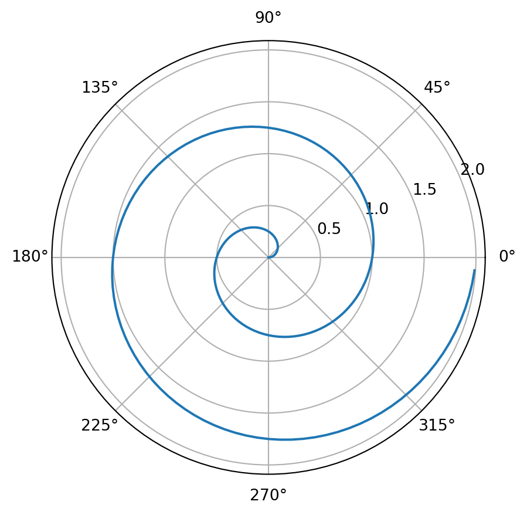

```python
import numpy as np
import matplotlib.pyplot as plt

r = np.arange(0, 2, 0.01)
theta = 2 * np.pi * r
fig, ax = plt.subplots(subplot_kw={"projection": "polar"})
ax.plot(theta, r)
ax.set_rticks([0.5, 1, 1.5, 2])
ax.grid(True)
plt.show()
```

## Configurações VSCode

Para executar um bloco de códigos Python no VSCode, você pode utilizar o atalho `Shift + Enter`. Para isso, você deve ter o Jupyter instalado e a extensão do Jupyter no VSCode. Também é necessário **habilitar a configuração** `Run Code` no VSCode. Para isso, clique no ícone de engrenagem no canto inferior esquerdo do VSCode e selecione **Settings**. Na barra de busca, digite `execute selection` e habilite a opção **Jupyter › Interactive Window › Text Editor: Execute Selection**.

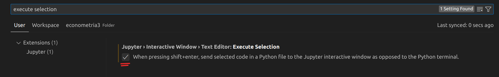

## Notas de rodapé

[^1]: Nos laboratórios da UDESC o VSCode já está instalado